# Outcomes in ESRD Patients Following Valve Replacement: Comparing Mechanical, Bioprosthetic, and TAVR Options

BMIN503/EPID600 Final Project

Author

Ziwei Pan

## 1 Overview

I investigated the impact of different valve procedures on mortality rates among patients with end-stage renal disease (ESRD), while accounting for the competing risk of kidney transplantation. I cleaned and filtered the Medicare and carrier claim datasets, focusing on patients who have undergone open-chest aortic valve replacement (mechanical AVR/ bioprosthetic AVR) or minimally invasive transcatheter aortic valve replacement (TAVR). This analysis aims to utilize survival analysis and competing risk modeling to identify the most suitable valve procedure for ESRD patients based on survival outcomes.

> https://github.com/ziwei-selinapan/BMIN503_Final_Project

## 2 Introduction

Dialysis patients undergoing surgical aortic valve replacement (SAVR) tend to have poor survival outcomes, with median survival rates often reported at two years or less. Due to the high surgical risks associated with dialysis patients, the best choice of prosthesis—whether bioprosthetic (bAVR) or mechanical (mAVR)—remains a subject of debate. The current guidelines from the ACC/AHA do not favor one type of valve over the other but instead recommend that surgeons consider patient-specific factors, including the risks of bleeding and valve deterioration, when selecting a prosthesis. The increasing use of transcatheter aortic valve replacement (TAVR) has further complicated decision-making for dialysis patients. While earlier studies suggested similar survival rates between bAVR and mAVR in dialysis patients, recent research, including the largest meta-analysis to date, provides conflicting results. Additionally, there is variability in the reported risks of bleeding, reoperation, and stroke. Regarding the comparison of TAVR versus SAVR for dialysis patients, limited research has been conducted in this high-risk group. As such, these inconsistencies and uncertainties necessitate further exploration. This study aims to compare the outcomes of different prosthesis options for isolated de novo aortic valve replacement in dialysis patients, using a large, up-to-date review of Medicare data.

The problem of selecting the optimal prosthesis for dialysis patients undergoing aortic valve replacement using statistical model is inherently interdisciplinary, involving medicine, surgery, biostatistics, pharmacy, and health economics. Cardiologists provide insights into the cardiovascular and renal challenges these patients face clinically, while biostatisticians analyze large datasets, such as Medicare and claims data, to evaluate outcomes retrospectively and inform clinical decisions. During meetings with Dr. Waseem Lutfi and faculty from Cardiology, I gained valuable perspectives on how various factors influence prosthesis selection and kidney transplant wait times. Additionally, discussions with Dr. Jesse Y. Hsu helped me gain expertise in data cleaning, as well as refining the model settings for survival analysis and competing risks modeling. This collaboration across disciplines is essential to understanding the complex decision-making process for dialysis patients.

## 3 Methods

A retrospective cohort study was conducted with the exposure of AVR type, namely bAVR, mAVR, and TAVR. Two parallel but separate comparisons were made: first comparing bAVR to mAVR, then comparing SAVR (bAVR + mAVR) to TAVR. The primary outcome was overall survival up to five years. Secondary outcomes included long-term secondary outcomes up to five years. Long-term secondary outcomes were aortic valve reoperation (TAVR or SAVR), readmissions for: congestive heart failure, endocarditis, GI bleeding and other bleeding complications, cerebral hemorrhage, ischemic stroke, and kidney transplant.

```r
# Load necessary libraries
library(readr)
library(dplyr)
library(tidyr)
library(psych)
library(ggplot2)
library(ggthemes)
library(MatchIt)  # for propensity score matching
library(lmtest)   # for propensity score matching
library(sandwich) # for displaying propensity score matching result
library(table1)   # automatically generating tables
library(survival) # for survival analysis
library(cmprsk)   # for competing risk modeling
```

### 3.1 Descriptive Statistics

I began by examining the demographic overview within the database, stratified by the different valve types used in the procedures (i.e., mAVR, bAVR, and TAVR). I used the table1 function to generate a descriptive demographic table.

```r
# Read-in cleaned, anonymized data file:
cleaned_AVR_data <- read_csv("/Users/selinapan/Desktop/UPenn/Biomedical Informatics Certificate/BMIN5030/BMIN503_Final_Project/AVR_all_pts.csv")
table(cleaned_AVR_data$SEX)
```

```
    1     2
10016  5065
```

```r
table(cleaned_AVR_data$ESRD_year)
```

```
   1    2    3    4    5    6    7    8    9   10   11
 475 3059 2635 2304 1952 1538 1126  830  568  345  249
```

```r
table(cleaned_AVR_data$Elix_score)
```

```
   1    2    3    4    5    6    7    8    9   10   11   12   13   14   15   16
   3    6   60  239  523  804 1123 1504 1754 1835 1745 1625 1238  978  707  438
  17   18   19   20   21   22   23   24
 252  127   72   32    8    6    1    1
```

```r
# Add labels to valve_type
cleaned_AVR_data_labeled <- cleaned_AVR_data %>%
  mutate(
    valve_type = factor(valve_type,
                        levels = c(1, 2, 3),
                        labels = c("Mechanical", "Bioprosthetic", "TAVR")),
    SEX = factor(SEX, levels = c(1, 2), labels = c("Male", "Female")),
    RACE = factor(RACE, levels = c(0, 1, 2, 3, 4, 5, 6),
                  labels = c("Unknown", "White", "Black", "Other", "Asian",
                             "Hispanic", "North American Native"))
  )

# Generate demographic descriptive table (table1)
table1_AVR <- table1(~ age + SEX + RACE + Elix_score + ESRD_year + CABG + PCI | valve_type,
                     data = cleaned_AVR_data_labeled,
                     overall = FALSE)
```

I then aggregate data to year and valve type level.

I plot a line graph displaying the yearly trend in the count of patients who chose each type of valve prosthesis. I also produce boxplots to show the distribution of patients’ Elixhauser scores (n = number of previous and present comorbidities) and age, which are two aspects crucial to predicting patients’ mortality outcomes.

```r
# Aggregate data to YEAR & valve_type level
aggregate_by_year <- cleaned_AVR_data_labeled %>%
  group_by(YEAR, valve_type) %>%
  summarize(patient_count = n_distinct(BENE_ID), .groups = "drop")

# Plot line graphs displaying yearly trend for number of patients of each procedure
year_trend <- ggplot(aggregate_by_year, aes(x = YEAR, y = patient_count, color = valve_type, group = valve_type)) +
  geom_line(size = 1) +
  geom_point(size = 3) +
  labs(
    title = "Yearly Trends by Valve Type",
    x = "Year",
    y = "Number of Patients",
    color = "Valve Type"
  ) +
  scale_x_continuous(breaks = seq(min(aggregate_by_year$YEAR), max(aggregate_by_year$YEAR), by = 1)) +
  theme_minimal() +
  theme(
    plot.title = element_text(hjust = 0.5, size = 14, face = "bold"),
    axis.text = element_text(size = 12),
    axis.title = element_text(size = 13)
  )
# Distribution of Elixhauser score by valve_type - patients who had TAVR had the highest Elixhauser comorbidity score, indicating that they are potentially the most sick.
Elix_boxplot <- ggplot(cleaned_AVR_data_labeled, aes(x = valve_type, y = Elix_score, fill = valve_type)) +
  geom_boxplot() +
  labs(
    title = "Distribution of Elixhauser Scores by Valve Type",
    x = "Valve Type",
    y = "Elixhauser Score"
  ) +
  theme_minimal() +
  theme(legend.position = "none")

# Distribution of age by valve_type - TAVR has the oldest patients, which might affect the interpretation of mortality model
age_boxplot <- ggplot(cleaned_AVR_data_labeled, aes(x = valve_type, y = age, fill = valve_type)) +
  geom_boxplot() +
  labs(
    title = "Distribution of Age by Valve Type",
    x = "Valve Type",
    y = "Elixhauser Score"
  ) +
  theme_minimal() +
  theme(legend.position = "none")
```

### 3.2 Propensity Score Matching

Love plots demonstrating standardized mean differences before and after matching were used to assess matching balance of covariates with a 10% mean standardized difference cutoff for covariate match acceptability.

The first matching graph shows the standardized mean differences pre and post matching for mAVR and bAVR patients amongst matched covariates, indicating a well-balanced match. Matching yielded 2,463 patients in each group.

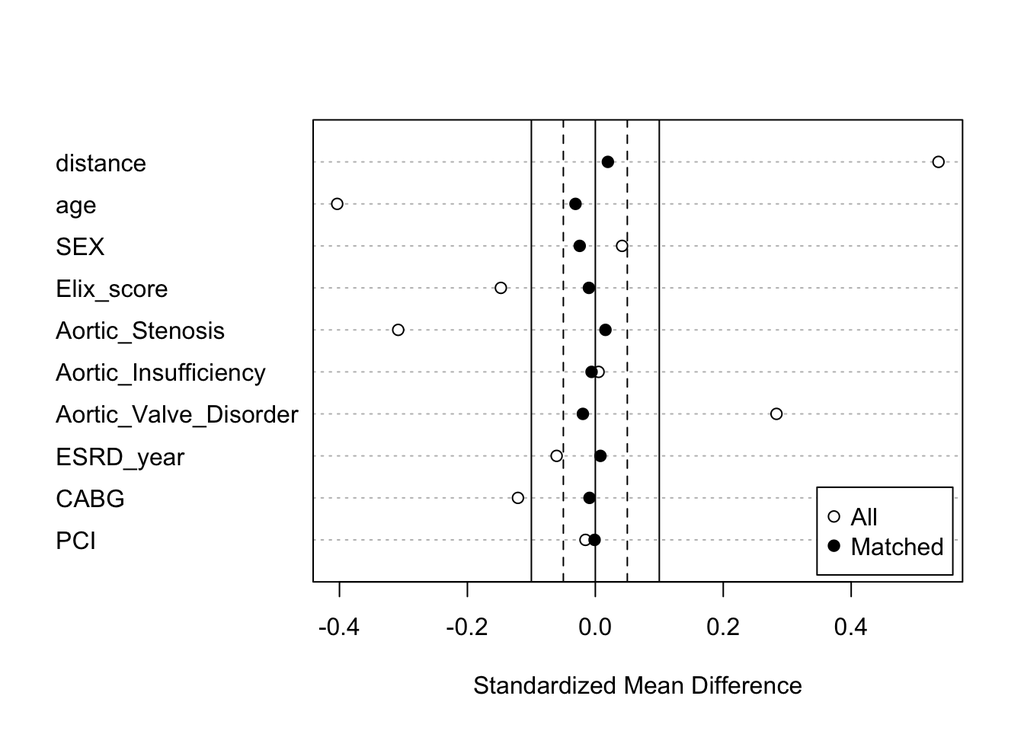

```r
##### Matching between mAVR and bAVR #####
# Keep only mechanical and bioprothetic AVR procedures, then do matching between mAVR and bAVR:
cleaned_mAVRbAVR_data <- cleaned_AVR_data %>%
  filter(valve_type %in% c("1", "2"))
# Assign bioprothetic = 0, mechanical = 1
cleaned_mAVRbAVR_data$valve_type[cleaned_mAVRbAVR_data$valve_type == 2] <- 0

# Matching
match_obj <- matchit(valve_type ~ age + SEX + Elix_score +
                       Aortic_Stenosis + Aortic_Insufficiency + Aortic_Valve_Disorder +
                       ESRD_year + CABG + PCI,
                     data = cleaned_mAVRbAVR_data, method = "nearest", distance = "glm",
                     ratio = 1,caliper = 0.1,
                     replace = FALSE)

# Plot the pre and post effects of propensity scores
matchplot_mAVRbAVR <- plot(summary(match_obj), abs = FALSE)
```

```r
# The standardized mean differences are all between -0.1 and 0.1 --> good match

# Export matched data
matched_SAVR_patients <- get_matches(
  match_obj,
  distance = "distance",
  weights = "weights",
  subclass = "subclass",
  id = "id",
  data = cleaned_mAVRbAVR_data,
  include.s.weights = TRUE
) # N = 4926 patients got matched

# Save to csv file
write_csv(matched_SAVR_patients, "/Users/selinapan/Desktop/UPenn/Biomedical Informatics Certificate/BMIN5030/BMIN503_Final_Project/matched_SAVR_patients.csv")

##### Matching between SAVR and TAVR #####
# Group mAVR and bAVR together as SAVR, then do matching with TAVR.
cleaned_SAVRTAVR_data <- cleaned_AVR_data
cleaned_SAVRTAVR_data$valve_type[cleaned_AVR_data$valve_type == 1 | cleaned_AVR_data$valve_type == 2] <- 0
cleaned_SAVRTAVR_data$valve_type[cleaned_AVR_data$valve_type == 3] <- 1
table(cleaned_SAVRTAVR_data$valve_type)
```

```
   0    1
7342 7739
```

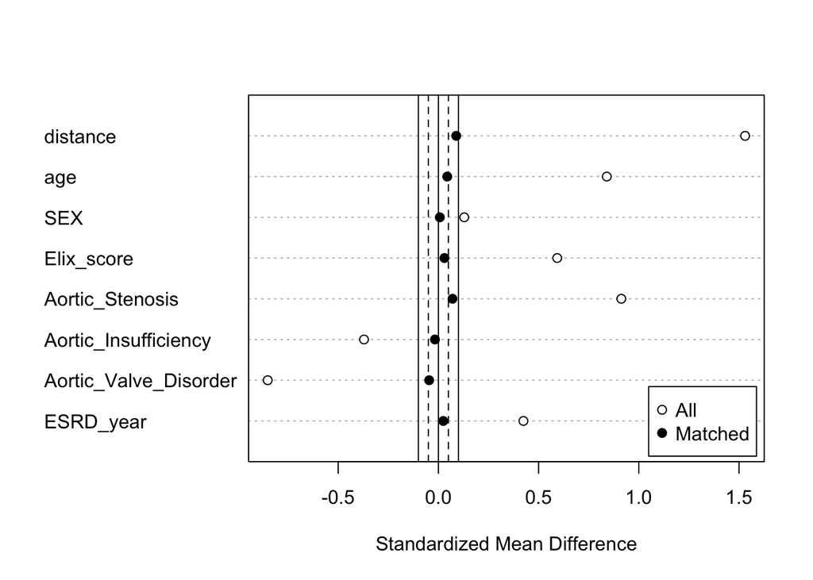

```r
match_obj <- matchit(valve_type ~ age + SEX + Elix_score +
                       Aortic_Stenosis + Aortic_Insufficiency +
                       Aortic_Valve_Disorder + ESRD_year,
                     data = cleaned_SAVRTAVR_data, method = "nearest", distance = "glm",
                     ratio = 1,caliper = 0.1,
                     replace = FALSE)
# Plot the pre and post effects of propensity scores
matchplot_SAVRTAVR <- plot(summary(match_obj), abs = FALSE)
```

```r
# standardized mean differences are all between -0.1 and 0.1 --> good match

matched_TAVR_patients <- get_matches(
  match_obj,
  distance = "distance",
  weights = "weights",
  subclass = "subclass",
  id = "id",
  data = cleaned_SAVRTAVR_data,
  include.s.weights = TRUE
) # N = 7588 patients got matched

# Export matched dataset
write_csv(matched_TAVR_patients, "/Users/selinapan/Desktop/UPenn/Biomedical Informatics Certificate/BMIN5030/BMIN503_Final_Project/matched_TAVR_patients.csv")
```

After obtaining the matched cohort, I revisited the original Medicare dataset to retrieve the patients’ admission records following their first valve prosthesis procedure. I then collapsed the data and restructured it to align with the requirements for competing risk modeling.

Following discussions with Dr. Hsu, I decided to use Fine and Gray’s competing risk model to analyze patient outcomes. This model is specifically designed to handle situations where multiple types of events can occur, with the occurrence of one event potentially preventing the occurrence of another.

Here I read in the two matched cohorts, and further prepare the data for modeling:

```r
# Read-in propensity matched data:
matched_TAVR_data_CRM <- read_csv("/Users/selinapan/Desktop/UPenn/Biomedical Informatics Certificate/BMIN5030/BMIN503_Final_Project/TAVR_CoxModel_matched.csv")
matched_SAVR_data_CRM <- read_csv("/Users/selinapan/Desktop/UPenn/Biomedical Informatics Certificate/BMIN5030/BMIN503_Final_Project/SAVR_CoxModel_matched.csv")
# TAVR = 1, SAVR = 0
matched_TAVR_data_CRM$valve_type[matched_TAVR_data_CRM$valve_type == 1 | matched_TAVR_data_CRM$valve_type == 2] <- 0
matched_TAVR_data_CRM$valve_type[matched_TAVR_data_CRM$valve_type == 3] <- 1
table(matched_TAVR_data_CRM$valve_type)
```

```
   0    1
6049 5710
```

```r
# mAVR = 1, bAVR = 0
matched_SAVR_data_CRM$valve_type[matched_SAVR_data_CRM$valve_type == 2] <- 0

# Mark patients who survived --> Event_name == 0
matched_TAVR_data_CRM <- matched_TAVR_data_CRM %>%
  mutate(Event_name = replace_na(Event_name, 0))
matched_SAVR_data_CRM <- matched_SAVR_data_CRM %>%
  mutate(Event_name = replace_na(Event_name, 0))

# Calculate ftime = Event_date (death date or secondary procedure date) - Procedure_date (initial valve procedure date)
matched_TAVR_data_CRM$ftime <- matched_TAVR_data_CRM$Event_date - matched_TAVR_data_CRM$Procedure_date
matched_SAVR_data_CRM$ftime <- matched_SAVR_data_CRM$Event_date - matched_SAVR_data_CRM$Procedure_date

# Replace ftime when Event_date is missing (NA) and Event_name == 0
# If a patient has Event_name == 0, it means that they did not die until the end time of dataset (end of 2019).
# So I am replacing their ftime = 21915 - Procedure date.
# 21915 represent the last day of 2019.
# (Note: This dataset stores some of the dates as continuous numbers,
# it assumes Jan. 1st 1960 as 0,
# On average there are 365.25 days in a year,
# 21915 / 365.25 = 60, 1960 + 60 = 2020
# so 21915 represent the last day of 2019)
matched_TAVR_data_CRM$ftime[is.na(matched_TAVR_data_CRM$Event_date) & matched_TAVR_data_CRM$Event_name == 0] <- 21915 - matched_TAVR_data_CRM$Procedure_date[is.na(matched_TAVR_data_CRM$Event_date)]
summary(matched_TAVR_data_CRM$ftime)
```

```
   Min. 1st Qu.  Median    Mean 3rd Qu.    Max.
    0.0    98.0   349.0   522.5   787.5  3631.0
```

```r
matched_SAVR_data_CRM$ftime[is.na(matched_SAVR_data_CRM$Event_date) & matched_SAVR_data_CRM$Event_name == 0] <- 21915 - matched_SAVR_data_CRM$Procedure_date[is.na(matched_SAVR_data_CRM$Event_date)]
summary(matched_SAVR_data_CRM$ftime)
```

```
   Min. 1st Qu.  Median    Mean 3rd Qu.    Max.
      0     145     520     767    1152    3862
```

```r
# Replace ndays_after_procedure with 0.1 if it's exactly 0
matched_TAVR_data_CRM$ftime[matched_TAVR_data_CRM$ftime == 0] <- 0.1
matched_SAVR_data_CRM$ftime[matched_SAVR_data_CRM$ftime == 0] <- 0.1
```

### 3.3 Competing Risk Modeling

Mortality and long-term secondary outcomes were compared using Fine‐Gray subdistribution hazard models with death and kidney transplant as a competing risk and displayed using cumulative incidence functions up to five years (7)

```r
# Displaying all the Event_name included: 0-9
# 0 represent patients who did not die by the end of 2019
# 1 represent patietns who died
# 2 represent patients who got kidney transplant - the competing risk factor
# 3-9 represent seven different secondary outcomes
table(matched_TAVR_data_CRM$Event_name)
```

```
   0    1    2    3    4    5    6    7    8    9
2071 3857  181  133  490  434  154 1516 2173  750
```

```r
table(matched_SAVR_data_CRM$Event_name)
```

```
   0    1    2    3    4    5    6    7    8    9
1319 3615  358  251  711  565  199 1471 2162  696
```

```r
# Competing risk modeling: Fine and Gray's model
# Failcode = 1, represent death (we are looking at mortality as primary outcome)
# cencode = 0, meaning I'm cencoring out patients who did not die

##### SAVR vs TAVR #####
matched_TAVR_data_mortality <- matched_TAVR_data_CRM %>%
  filter(Event_name %in% c(0, 1, 2))

fg_TAVR_mort <- crr(ftime = matched_TAVR_data_mortality$ftime,
          fstatus = matched_TAVR_data_mortality$Event_name,
          cov1 = matched_TAVR_data_mortality$valve_type,
          failcode = 1,
          cencode = 0)
# considering adding covariates in the future: cov2 = ?

# Calculating cumulative incidence
cif <- cuminc(ftime = matched_TAVR_data_mortality$ftime,
              fstatus = matched_TAVR_data_mortality$Event_name,
              group = matched_TAVR_data_mortality$valve_type)
# Plot cumulative incidence
png("TAVR_mort_cif.png", width = 800, height = 600)
TAVR_mort_cif <- plot(cif,
     xlab = "Time",
     ylab = "Cumulative Incidence",
     main = "Cumulative Incidence by Group",
     lwd = 2,
     xlim = c(0, 1826)) # Limit x-axis to 5 years after procedure
dev.off()
```

```r
##### mAVR vs bAVR #####
matched_SAVR_data_mortality <- matched_SAVR_data_CRM %>%
  filter(Event_name %in% c(0, 1, 2))

fg_SAVR_mort <- crr(ftime = matched_SAVR_data_mortality$ftime,
          fstatus = matched_SAVR_data_mortality$Event_name,
          cov1 = matched_SAVR_data_mortality$valve_type,
          failcode = 1,
          cencode = 0)

# Calculating cumulative incidence
cif <- cuminc(ftime = matched_SAVR_data_mortality$ftime,
              fstatus = matched_SAVR_data_mortality$Event_name,
              group = matched_SAVR_data_mortality$valve_type)
# Plot cumulative incidence
png("SAVR_mort_cif.png", width = 800, height = 600)
SAVR_mort_cif <- plot(cif,
     xlab = "Time",
     ylab = "Cumulative Incidence",
     main = "Cumulative Incidence by Group",
     lwd = 2,
     xlim = c(0, 1826)) # Limit x-axis to 5 years after procedure
dev.off()
```

Secondary outcomes:

```r
###################################
#####      mAVR vs. bAVR      #####
###################################

##### Reoperation #####
matched_SAVR_data_reop <- matched_SAVR_data_CRM %>%
  filter(Event_name %in% c(0, 1, 2, 3))

fg_savr_reop <- crr(ftime = matched_SAVR_data_reop$ftime,
          fstatus = matched_SAVR_data_reop$Event_name,
          cov1 = matched_SAVR_data_reop$valve_type,
          failcode = 3,
          cencode = 0)

# Calculating cumulative incidence
cif <- cuminc(ftime = matched_SAVR_data_reop$ftime,
              fstatus = matched_SAVR_data_reop$Event_name,
              group = matched_SAVR_data_reop$valve_type)
cif_subset <- cif[grep(paste0(" ", 3), names(cif))]

# Plot cumulative incidence
png("SAVR_reop_cif.png", width = 800, height = 600)
SAVR_reop_cif <- plot(cif_subset,
     xlab = "Time",
     ylab = "Cumulative Incidence",
     main = "Cumulative Incidence by Group",
     lwd = 2,
     ylim = c(0, 0.08),
     xlim = c(0, 1826)) # Limit x-axis to 5 years after procedure
dev.off()
```

```r
##### Readmission for Congestive Heart Failure (CHF) #####
matched_SAVR_data_CHF <- matched_SAVR_data_CRM %>%
  filter(Event_name %in% c(0, 1, 2, 4))

fg_savr_CHF <- crr(ftime = matched_SAVR_data_CHF$ftime,
          fstatus = matched_SAVR_data_CHF$Event_name,
          cov1 = matched_SAVR_data_CHF$valve_type,
          failcode = 4,
          cencode = 0)

# Calculating cumulative incidence
cif <- cuminc(ftime = matched_SAVR_data_CHF$ftime,
              fstatus = matched_SAVR_data_CHF$Event_name,
              group = matched_SAVR_data_CHF$valve_type)
cif_subset <- cif[grep(paste0(" ", 4), names(cif))]

# Plot cumulative incidence
png("SAVR_CHF_cif.png", width = 800, height = 600)
SAVR_CHF_cif <- plot(cif_subset,
     xlab = "Time",
     ylab = "Cumulative Incidence",
     main = "Cumulative Incidence by Group",
     lwd = 2,
     ylim = c(0, 0.2),
     xlim = c(0, 1826)) # Limit x-axis to 5 years after procedure
dev.off()
```

```r
##### Readmission for Endocarditis #####
matched_SAVR_data_endo <- matched_SAVR_data_CRM %>%
  filter(Event_name %in% c(0, 1, 2, 5))

fg_savr_endo <- crr(ftime = matched_SAVR_data_endo$ftime,
          fstatus = matched_SAVR_data_endo$Event_name,
          cov1 = matched_SAVR_data_endo$valve_type,
          failcode = 5,
          cencode = 0)

# Calculating cumulative incidence
cif <- cuminc(ftime = matched_SAVR_data_endo$ftime,
              fstatus = matched_SAVR_data_endo$Event_name,
              group = matched_SAVR_data_endo$valve_type)
cif_subset <- cif[grep(paste0(" ", 5), names(cif))]

# Plot cumulative incidence
png("SAVR_endo_cif.png", width = 800, height = 600)
SAVR_endo_cif <- plot(cif_subset,
     xlab = "Time",
     ylab = "Cumulative Incidence",
     main = "Cumulative Incidence by Group",
     lwd = 2,
     ylim = c(0, 0.15),
     xlim = c(0, 1826)) # Limit x-axis to 5 years after procedure
dev.off()
```

```r
##### Readmission for Cerebral Hemorrhage #####
matched_SAVR_data_cerebral <- matched_SAVR_data_CRM %>%
  filter(Event_name %in% c(0, 1, 2, 6))

fg_savr_cerebral <- crr(ftime = matched_SAVR_data_cerebral$ftime,
          fstatus = matched_SAVR_data_cerebral$Event_name,
          cov1 = matched_SAVR_data_cerebral$valve_type,
          failcode = 6,
          cencode = 0)

# Calculating cumulative incidence
cif <- cuminc(ftime = matched_SAVR_data_cerebral$ftime,
              fstatus = matched_SAVR_data_cerebral$Event_name,
              group = matched_SAVR_data_cerebral$valve_type)
cif_subset <- cif[grep(paste0(" ", 6), names(cif))]

# Plot cumulative incidence
png("SAVR_cerebral_cif.png", width = 800, height = 600)
SAVR_cerebral_cif <- plot(cif_subset,
     xlab = "Time",
     ylab = "Cumulative Incidence",
     main = "Cumulative Incidence by Group",
     lwd = 2,
     ylim = c(0, 0.08),
     xlim = c(0, 1826)) # Limit x-axis to 5 years after procedure
dev.off()
```

```r
##### Readmission for GI Bleeding #####
matched_SAVR_data_GI <- matched_SAVR_data_CRM %>%
  filter(Event_name %in% c(0, 1, 2, 7))

fg_savr_GI <- crr(ftime = matched_SAVR_data_GI$ftime,
          fstatus = matched_SAVR_data_GI$Event_name,
          cov1 = matched_SAVR_data_GI$valve_type,
          failcode = 7,
          cencode = 0)

# Calculating cumulative incidence
cif <- cuminc(ftime = matched_SAVR_data_GI$ftime,
              fstatus = matched_SAVR_data_GI$Event_name,
              group = matched_SAVR_data_GI$valve_type)
cif_subset <- cif[grep(paste0(" ", 7), names(cif))]

# Plot cumulative incidence
png("SAVR_GI_cif.png", width = 800, height = 600)
SAVR_GI_cif <- plot(cif_subset,
     xlab = "Time",
     ylab = "Cumulative Incidence",
     main = "Cumulative Incidence by Group",
     lwd = 2,
     ylim = c(0, 0.25),
     xlim = c(0, 1826)) # Limit x-axis to 5 years after procedure
dev.off()
```

```r
##### Readmission for Other Bleeding #####
matched_SAVR_data_otherbleed <- matched_SAVR_data_CRM %>%
  filter(Event_name %in% c(0, 1, 2, 8))

fg_savr_otherbleed <- crr(ftime = matched_SAVR_data_otherbleed$ftime,
          fstatus = matched_SAVR_data_otherbleed$Event_name,
          cov1 = matched_SAVR_data_otherbleed$valve_type,
          failcode = 8,
          cencode = 0)

# Calculating cumulative incidence
cif <- cuminc(ftime = matched_SAVR_data_otherbleed$ftime,
              fstatus = matched_SAVR_data_otherbleed$Event_name,
              group = matched_SAVR_data_otherbleed$valve_type)
cif_subset <- cif[grep(paste0(" ", 8), names(cif))]

# Plot cumulative incidence
png("SAVR_otherbleed_cif.png", width = 800, height = 600)
SAVR_otherbleed_cif <- plot(cif_subset,
     xlab = "Time",
     ylab = "Cumulative Incidence",
     main = "Cumulative Incidence by Group",
     lwd = 2,
     ylim = c(0, 0.3),
     xlim = c(0, 1826)) # Limit x-axis to 5 years after procedure
dev.off()
```

```r
##### Readmission for Ischemic Stroke #####
matched_SAVR_data_stroke <- matched_SAVR_data_CRM %>%
  filter(Event_name %in% c(0, 1, 2, 9))

fg_savr_stroke <- crr(ftime = matched_SAVR_data_stroke$ftime,
          fstatus = matched_SAVR_data_stroke$Event_name,
          cov1 = matched_SAVR_data_stroke$valve_type,
          failcode = 9,
          cencode = 0)

# Calculating cumulative incidence
cif <- cuminc(ftime = matched_SAVR_data_stroke$ftime,
              fstatus = matched_SAVR_data_stroke$Event_name,
              group = matched_SAVR_data_stroke$valve_type)
cif_subset <- cif[grep(paste0(" ", 9), names(cif))]

# Plot cumulative incidence
png("SAVR_stroke_cif.png", width = 800, height = 600)
SAVR_stroke_cif <- plot(cif_subset,
     xlab = "Time",
     ylab = "Cumulative Incidence",
     main = "Cumulative Incidence by Group",
     lwd = 2,
     ylim = c(0, 0.15),
     xlim = c(0, 1826)) # Limit x-axis to 5 years after procedure
dev.off()
```

```r
###################################
#####      SAVR vs. TAVR      #####
###################################

##### Reoperation #####
matched_TAVR_data_reop <- matched_TAVR_data_CRM %>%
  filter(Event_name %in% c(0, 1, 2, 3))

fg_tavr_reop <- crr(ftime = matched_TAVR_data_reop$ftime,
          fstatus = matched_TAVR_data_reop$Event_name,
          cov1 = matched_TAVR_data_reop$valve_type,
          failcode = 3,
          cencode = 0)

# Calculating cumulative incidence
cif <- cuminc(ftime = matched_TAVR_data_reop$ftime,
              fstatus = matched_TAVR_data_reop$Event_name,
              group = matched_TAVR_data_reop$valve_type)
cif_subset <- cif[grep(paste0(" ", 3), names(cif))]

# Plot cumulative incidence
png("TAVR_reop_cif.png", width = 800, height = 600)
TAVR_reop_cif <- plot(cif_subset,
     xlab = "Time",
     ylab = "Cumulative Incidence",
     main = "Cumulative Incidence by Group",
     lwd = 2,
     ylim = c(0, 0.05),
     xlim = c(0, 1826)) # Limit x-axis to 5 years after procedure
dev.off()
```

```r
##### Readmission for Congestive Heart Failure (CHF) #####
matched_TAVR_data_CHF <- matched_TAVR_data_CRM %>%
  filter(Event_name %in% c(0, 1, 2, 4))

fg_tavr_CHF <- crr(ftime = matched_TAVR_data_CHF$ftime,
          fstatus = matched_TAVR_data_CHF$Event_name,
          cov1 = matched_TAVR_data_CHF$valve_type,
          failcode = 4,
          cencode = 0)

# Calculating cumulative incidence
cif <- cuminc(ftime = matched_TAVR_data_CHF$ftime,
              fstatus = matched_TAVR_data_CHF$Event_name,
              group = matched_TAVR_data_CHF$valve_type)
cif_subset <- cif[grep(paste0(" ", 4), names(cif))]

# Plot cumulative incidence
png("TAVR_CHF_cif.png", width = 800, height = 600)
TAVR_CHF_cif <- plot(cif_subset,
     xlab = "Time",
     ylab = "Cumulative Incidence",
     main = "Cumulative Incidence by Group",
     lwd = 2,
     ylim = c(0, 0.15),
     xlim = c(0, 1826)) # Limit x-axis to 5 years after procedure
dev.off()
```

```r
##### Readmission for Endocarditis #####
matched_TAVR_data_endo <- matched_TAVR_data_CRM %>%
  filter(Event_name %in% c(0, 1, 2, 5))

fg_tavr_endo <- crr(ftime = matched_TAVR_data_endo$ftime,
          fstatus = matched_TAVR_data_endo$Event_name,
          cov1 = matched_TAVR_data_endo$valve_type,
          failcode = 5,
          cencode = 0)

# Calculating cumulative incidence
cif <- cuminc(ftime = matched_TAVR_data_endo$ftime,
              fstatus = matched_TAVR_data_endo$Event_name,
              group = matched_TAVR_data_endo$valve_type)
cif_subset <- cif[grep(paste0(" ", 5), names(cif))]

# Plot cumulative incidence
png("TAVR_endo_cif.png", width = 800, height = 600)
TAVR_endo_cif <- plot(cif_subset,
     xlab = "Time",
     ylab = "Cumulative Incidence",
     main = "Cumulative Incidence by Group",
     lwd = 2,
     ylim = c(0, 0.1),
     xlim = c(0, 1826)) # Limit x-axis to 5 years after procedure
dev.off()
```

```r
##### Readmission for Cerebral Hemorrhage #####
matched_TAVR_data_cerebral <- matched_TAVR_data_CRM %>%
  filter(Event_name %in% c(0, 1, 2, 6))

fg_tavr_cerebral <- crr(ftime = matched_TAVR_data_cerebral$ftime,
          fstatus = matched_TAVR_data_cerebral$Event_name,
          cov1 = matched_TAVR_data_cerebral$valve_type,
          failcode = 6,
          cencode = 0)

# Calculating cumulative incidence
cif <- cuminc(ftime = matched_TAVR_data_cerebral$ftime,
              fstatus = matched_TAVR_data_cerebral$Event_name,
              group = matched_TAVR_data_cerebral$valve_type)
cif_subset <- cif[grep(paste0(" ", 6), names(cif))]

# Plot cumulative incidence
png("TAVR_cerebral_cif.png", width = 800, height = 600)
TAVR_cerebral_cif <- plot(cif_subset,
     xlab = "Time",
     ylab = "Cumulative Incidence",
     main = "Cumulative Incidence by Group",
     lwd = 2,
     ylim = c(0, 0.05),
     xlim = c(0, 1826)) # Limit x-axis to 5 years after procedure
dev.off()
```

```r
##### Readmission for GI Bleeding #####
matched_TAVR_data_GI <- matched_TAVR_data_CRM %>%
  filter(Event_name %in% c(0, 1, 2, 7))

fg_tavr_GI <- crr(ftime = matched_TAVR_data_GI$ftime,
          fstatus = matched_TAVR_data_GI$Event_name,
          cov1 = matched_TAVR_data_GI$valve_type,
          failcode = 7,
          cencode = 0)

# Calculating cumulative incidence
cif <- cuminc(ftime = matched_TAVR_data_GI$ftime,
              fstatus = matched_TAVR_data_GI$Event_name,
              group = matched_TAVR_data_GI$valve_type)
cif_subset <- cif[grep(paste0(" ", 7), names(cif))]

# Plot cumulative incidence
png("TAVR_GI_cif.png", width = 800, height = 600)
TAVR_GI_cif <- plot(cif_subset,
     xlab = "Time",
     ylab = "Cumulative Incidence",
     main = "Cumulative Incidence by Group",
     lwd = 2,
     ylim = c(0, 0.3),
     xlim = c(0, 1826)) # Limit x-axis to 5 years after procedure
dev.off()
```

```r
##### Readmission for Other Bleeding #####
matched_TAVR_data_otherbleed <- matched_TAVR_data_CRM %>%
  filter(Event_name %in% c(0, 1, 2, 8))

fg_tavr_otherbleed <- crr(ftime = matched_TAVR_data_otherbleed$ftime,
          fstatus = matched_TAVR_data_otherbleed$Event_name,
          cov1 = matched_TAVR_data_otherbleed$valve_type,
          failcode = 8,
          cencode = 0)

# Calculating cumulative incidence
cif <- cuminc(ftime = matched_TAVR_data_otherbleed$ftime,
              fstatus = matched_TAVR_data_otherbleed$Event_name,
              group = matched_TAVR_data_otherbleed$valve_type)
cif_subset <- cif[grep(paste0(" ", 8), names(cif))]

# Plot cumulative incidence
png("TAVR_otherbleed_cif.png", width = 800, height = 600)
TAVR_otherbleed_cif <- plot(cif_subset,
     xlab = "Time",
     ylab = "Cumulative Incidence",
     main = "Cumulative Incidence by Group",
     lwd = 2,
     ylim = c(0, 0.35),
     xlim = c(0, 1826)) # Limit x-axis to 5 years after procedure
dev.off()
```

```r
##### Readmission for Ischemic Stroke #####
matched_TAVR_data_stroke <- matched_TAVR_data_CRM %>%
  filter(Event_name %in% c(0, 1, 2, 9))

fg_tavr_stroke <- crr(ftime = matched_TAVR_data_stroke$ftime,
          fstatus = matched_TAVR_data_stroke$Event_name,
          cov1 = matched_TAVR_data_stroke$valve_type,
          failcode = 9,
          cencode = 0)

# Calculating cumulative incidence
cif <- cuminc(ftime = matched_TAVR_data_stroke$ftime,
              fstatus = matched_TAVR_data_stroke$Event_name,
              group = matched_TAVR_data_stroke$valve_type)
cif_subset <- cif[grep(paste0(" ", 9), names(cif))]

# Plot cumulative incidence
png("TAVR_stroke_cif.png", width = 800, height = 600)
TAVR_stroke_cif <- plot(cif_subset,
     xlab = "Time",
     ylab = "Cumulative Incidence",
     main = "Cumulative Incidence by Group",
     lwd = 2,
     ylim = c(0, 0.15),
     xlim = c(0, 1826)) # Limit x-axis to 5 years after procedure
dev.off()
```

## 4 Results

After patient selection, 15,081 patients were included for analysis; the average age was 69.1 years, 66.4% of patients were male, 67.1% were white, 23.4% were black, and the mean years on dialysis at the time of AVR was 4.6 years.

Table 1 demonstrates the cohort characteristics by AVR type prior to propensity score matching. 2,590 patients underwent mAVR, 4,752 bAVR, and 7,739 TAVR; respectively, the mean ages were 61.5, 66.6, and 73.2 years (P<0.001) and mean Elixhauser scores were 9.2, 9.7, and 11.3 (P<0.001) as shown in boxplots of age and Elixhauser scores, indicating that mAVR patients were the youngest and with fewer comorbidities while TAVR patients were the oldest with highest comorbidity burden. 1,080 (41.7%) mAVR patients had a concomitant coronary artery bypass graft (CABG) compared to 2,264 (47.7%) bAVR, and rates of percutaneous coronary intervention (PCI) within 3 months of AVR were 359 (13.9%), 684 (14.4%) and 1,788 (23.1%) for mAVR, bAVR, and TAVR respectfully.

```r
table1_AVR
```

|  | Mechanical (N=2590) | Bioprosthetic (N=4752) | TAVR (N=7739) |
| --- | --- | --- | --- |
| age |  |  |  |
| Mean (SD) | 61.5 (12.6) | 66.6 (10.7) | 73.1 (9.96) |
| Median [Min, Max] | 62.4 [21.3, 90.7] | 67.6 [4.32, 93.6] | 74.0 [29.5, 99.0] |
| SEX |  |  |  |
| Male | 1770 (68.3%) | 3340 (70.3%) | 4906 (63.4%) |
| Female | 820 (31.7%) | 1412 (29.7%) | 2833 (36.6%) |
| RACE |  |  |  |
| Unknown | 16 (0.6%) | 47 (1.0%) | 74 (1.0%) |
| White | 1588 (61.3%) | 3024 (63.6%) | 5507 (71.2%) |
| Black | 751 (29.0%) | 1263 (26.6%) | 1509 (19.5%) |
| Other | 51 (2.0%) | 117 (2.5%) | 182 (2.4%) |
| Asian | 43 (1.7%) | 88 (1.9%) | 179 (2.3%) |
| Hispanic | 117 (4.5%) | 179 (3.8%) | 226 (2.9%) |
| North American Native | 24 (0.9%) | 34 (0.7%) | 62 (0.8%) |
| Elix_score |  |  |  |
| Mean (SD) | 9.24 (3.04) | 9.69 (3.09) | 11.3 (3.03) |
| Median [Min, Max] | 9.00 [1.00, 20.0] | 9.00 [1.00, 22.0] | 11.0 [3.00, 24.0] |
| ESRD_year |  |  |  |
| Mean (SD) | 3.92 (2.09) | 4.05 (2.12) | 5.06 (2.49) |
| Median [Min, Max] | 3.00 [1.00, 11.0] | 4.00 [1.00, 11.0] | 5.00 [1.00, 11.0] |
| CABG |  |  |  |
| Mean (SD) | 0.417 (0.493) | 0.477 (0.500) | 0.00194 (0.0440) |
| Median [Min, Max] | 0 [0, 1.00] | 0 [0, 1.00] | 0 [0, 1.00] |
| PCI |  |  |  |
| Mean (SD) | 0.139 (0.346) | 0.144 (0.351) | 0.231 (0.422) |
| Median [Min, Max] | 0 [0, 1.00] | 0 [0, 1.00] | 0 [0, 1.00] |

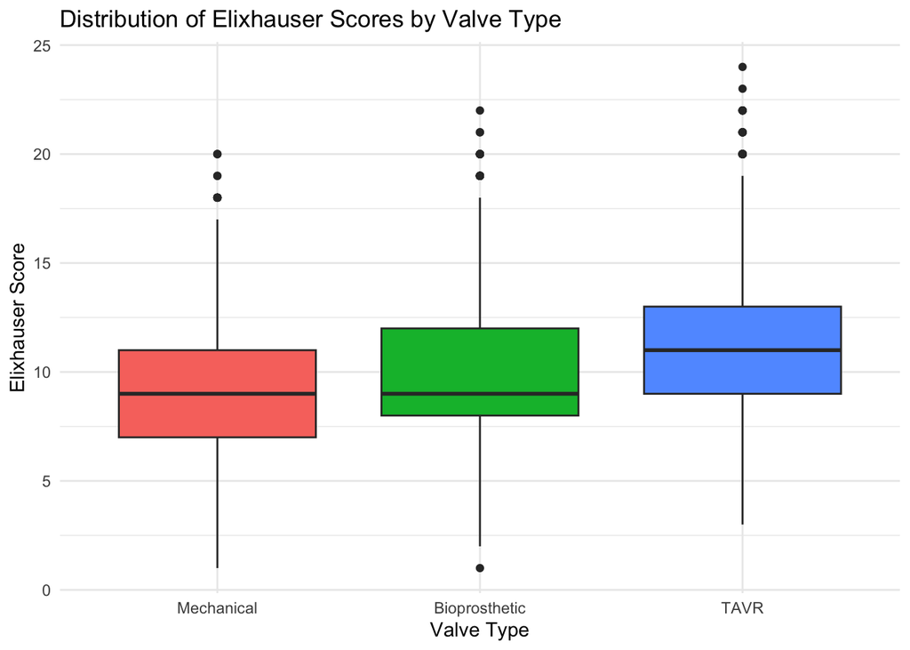

```r
Elix_boxplot
```

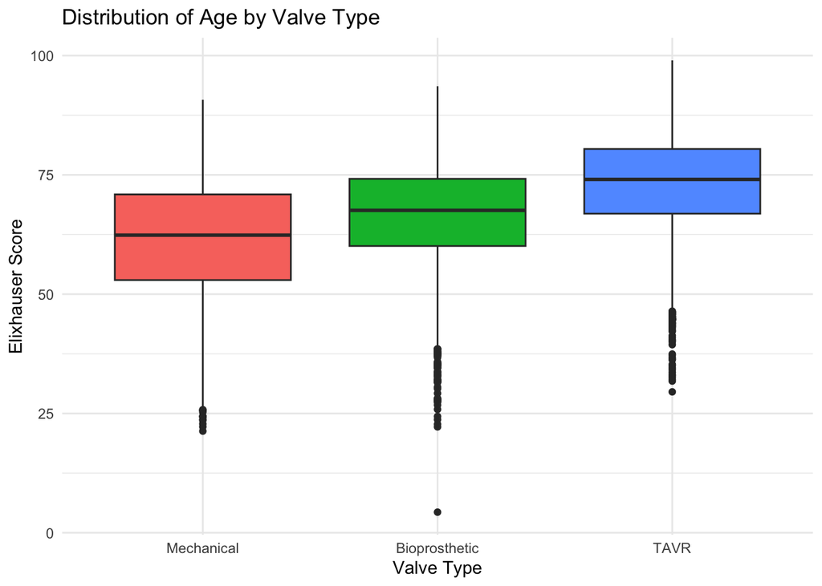

```r
age_boxplot
```

The trend of AVR type from 2009 to 2019 shows as a line plot that there is a rapid increase in the number of TAVR procedures while the number of bAVR and mAVR decrease over the period studied. By 2015, the number of TAVR procedures is greater than the number of bAVR and mAVR combined.

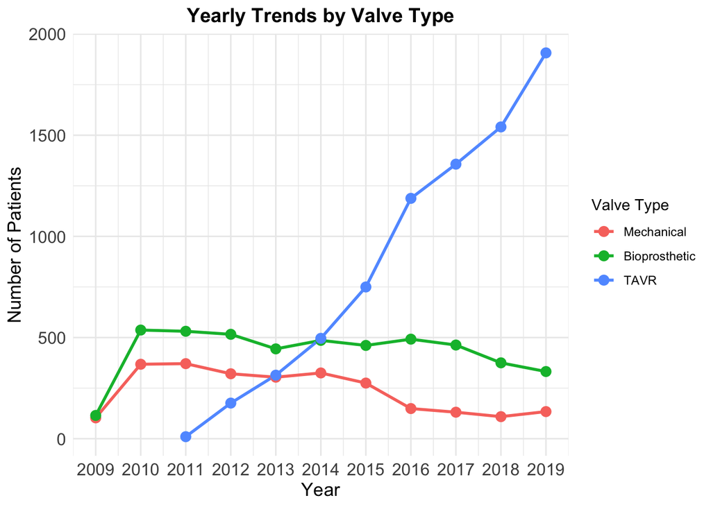

```r
year_trend
```

**Cumulative incidence figures and model summaries for mortality outcome.**

Note:

- In TAVR matched cohort, TAVR is marked with valve_type = 1. SAVR is marked with valve_type = 0.
- In SAVR matched cohort, mAVR is marked with valve_type = 1. bAVR is marked with valve_type = 0.

```r
summary(fg_TAVR_mort)
```

```
Competing Risks Regression

Call:
crr(ftime = matched_TAVR_data_mortality$ftime, fstatus = matched_TAVR_data_mortality$Event_name,
    cov1 = matched_TAVR_data_mortality$valve_type, failcode = 1,
    cencode = 0)

                                         coef exp(coef) se(coef)    z p-value
matched_TAVR_data_mortality$valve_type1 0.168      1.18   0.0322 5.21 1.8e-07

                                        exp(coef) exp(-coef) 2.5% 97.5%
matched_TAVR_data_mortality$valve_type1      1.18      0.845 1.11  1.26

Num. cases = 6109
Pseudo Log-likelihood = -30469
Pseudo likelihood ratio test = 26.6  on 1 df,
```

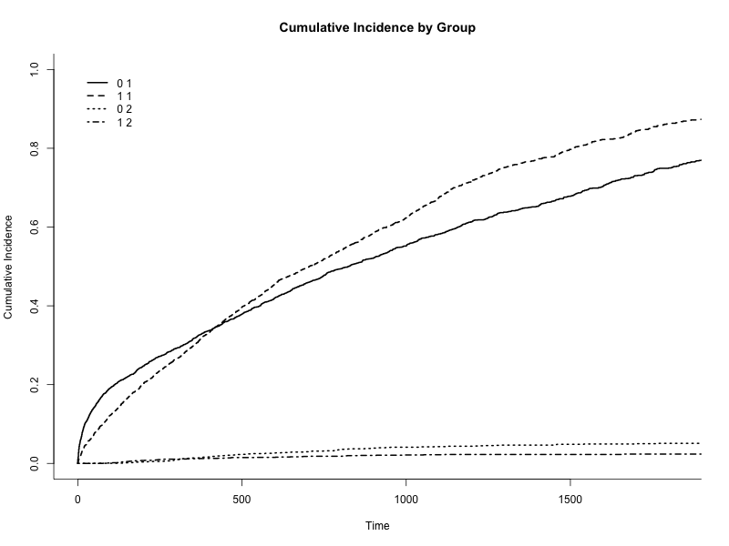

```r
knitr::include_graphics("TAVR_mort_cif.png")
```

```r
summary(fg_SAVR_mort)
```

```
Competing Risks Regression

Call:
crr(ftime = matched_SAVR_data_mortality$ftime, fstatus = matched_SAVR_data_mortality$Event_name,
    cov1 = matched_SAVR_data_mortality$valve_type, failcode = 1,
    cencode = 0)

                                           coef exp(coef) se(coef)      z
matched_SAVR_data_mortality$valve_type1 -0.0299     0.971    0.033 -0.904
                                        p-value
matched_SAVR_data_mortality$valve_type1    0.37

                                        exp(coef) exp(-coef) 2.5% 97.5%
matched_SAVR_data_mortality$valve_type1     0.971       1.03 0.91  1.04

Num. cases = 5292
Pseudo Log-likelihood = -28565
Pseudo likelihood ratio test = 0.81  on 1 df,
```

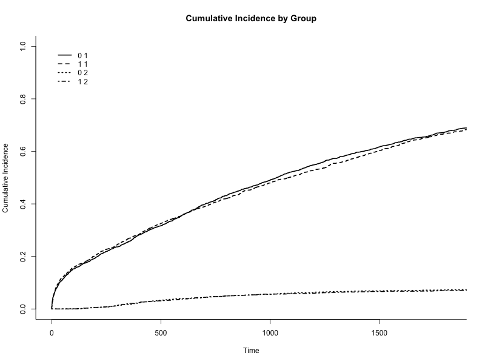

```r
knitr::include_graphics("SAVR_mort_cif.png")
```

**Cumulative incidence figures and model summaries for long-term secondary outcomes.**

**The figures show the cumulative incidence curves for the long-term secondary outcomes between matched mAVR and bAVR patients; Compared to mAVR, at 5 years of follow-up bAVR patients were more likely to have valve reoperation (P < 0.05), less likely to have readmission for GI bleeding (P < 0.05), but similar cumulative incidence of ischemic stroke readmission, CHF readmission, endocarditis readmission, and kidney transplant.**

```r
summary(fg_savr_reop)
```

```
Competing Risks Regression

Call:
crr(ftime = matched_SAVR_data_reop$ftime, fstatus = matched_SAVR_data_reop$Event_name,
    cov1 = matched_SAVR_data_reop$valve_type, failcode = 3, cencode = 0)

                                     coef exp(coef) se(coef)     z p-value
matched_SAVR_data_reop$valve_type1 -0.572     0.564    0.132 -4.34 1.4e-05

                                   exp(coef) exp(-coef)  2.5% 97.5%
matched_SAVR_data_reop$valve_type1     0.564       1.77 0.436 0.731

Num. cases = 5543
Pseudo Log-likelihood = -2101
Pseudo likelihood ratio test = 19.6  on 1 df,
```

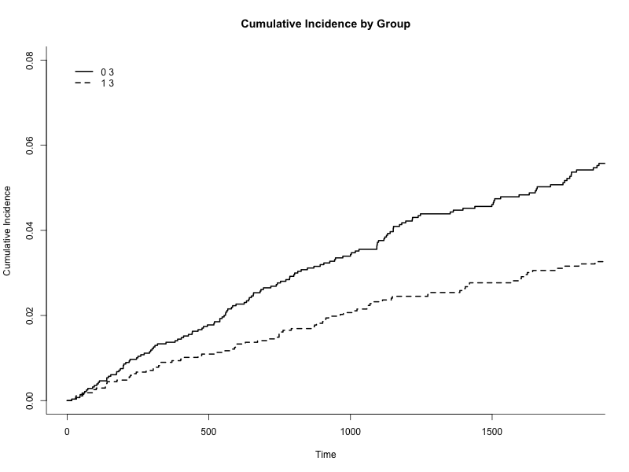

```r
knitr::include_graphics("SAVR_reop_cif.png")
```

```r
summary(fg_savr_CHF)
```

```
Competing Risks Regression

Call:
crr(ftime = matched_SAVR_data_CHF$ftime, fstatus = matched_SAVR_data_CHF$Event_name,
    cov1 = matched_SAVR_data_CHF$valve_type, failcode = 4, cencode = 0)

                                    coef exp(coef) se(coef)     z p-value
matched_SAVR_data_CHF$valve_type1 0.0561      1.06    0.075 0.748    0.45

                                  exp(coef) exp(-coef)  2.5% 97.5%
matched_SAVR_data_CHF$valve_type1      1.06      0.945 0.913  1.23

Num. cases = 6003
Pseudo Log-likelihood = -6106
Pseudo likelihood ratio test = 0.56  on 1 df,
```

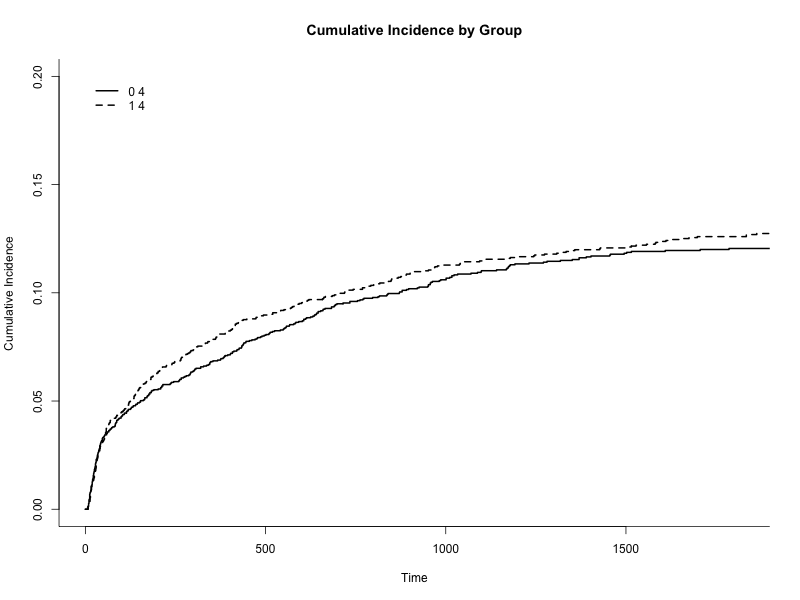

```r
knitr::include_graphics("SAVR_CHF_cif.png")
```

```r
summary(fg_savr_endo)
```

```
Competing Risks Regression

Call:
crr(ftime = matched_SAVR_data_endo$ftime, fstatus = matched_SAVR_data_endo$Event_name,
    cov1 = matched_SAVR_data_endo$valve_type, failcode = 5, cencode = 0)

                                       coef exp(coef) se(coef)       z p-value
matched_SAVR_data_endo$valve_type1 -0.00168     0.998   0.0841 -0.0199    0.98

                                   exp(coef) exp(-coef)  2.5% 97.5%
matched_SAVR_data_endo$valve_type1     0.998          1 0.847  1.18

Num. cases = 5857
Pseudo Log-likelihood = -4813
Pseudo likelihood ratio test = 0  on 1 df,
```

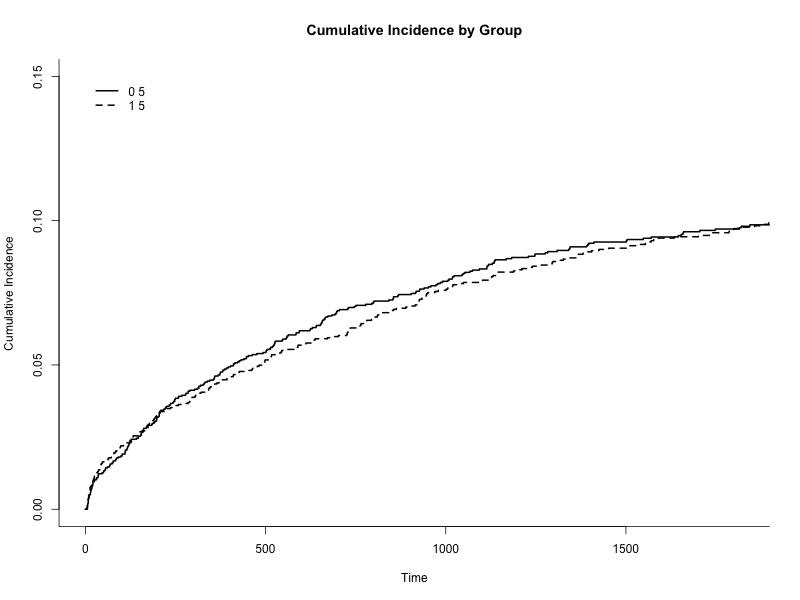

```r
knitr::include_graphics("SAVR_endo_cif.png")
```

```r
summary(fg_savr_cerebral)
```

```
Competing Risks Regression

Call:
crr(ftime = matched_SAVR_data_cerebral$ftime, fstatus = matched_SAVR_data_cerebral$Event_name,
    cov1 = matched_SAVR_data_cerebral$valve_type, failcode = 6,
    cencode = 0)

                                        coef exp(coef) se(coef)   z p-value
matched_SAVR_data_cerebral$valve_type1 0.199      1.22    0.142 1.4    0.16

                                       exp(coef) exp(-coef)  2.5% 97.5%
matched_SAVR_data_cerebral$valve_type1      1.22       0.82 0.923  1.61

Num. cases = 5491
Pseudo Log-likelihood = -1675
Pseudo likelihood ratio test = 1.96  on 1 df,
```

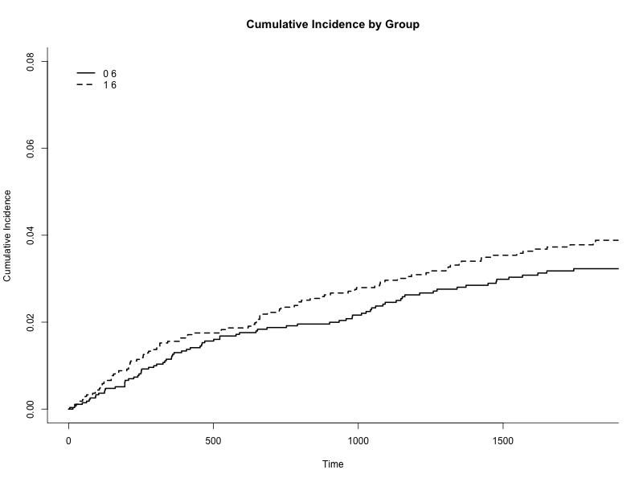

```r
knitr::include_graphics("SAVR_cerebral_cif.png")
```

```r
summary(fg_savr_GI)
```

```
Competing Risks Regression

Call:
crr(ftime = matched_SAVR_data_GI$ftime, fstatus = matched_SAVR_data_GI$Event_name,
    cov1 = matched_SAVR_data_GI$valve_type, failcode = 7, cencode = 0)

                                  coef exp(coef) se(coef)    z p-value
matched_SAVR_data_GI$valve_type1 0.158      1.17   0.0522 3.03  0.0024

                                 exp(coef) exp(-coef) 2.5% 97.5%
matched_SAVR_data_GI$valve_type1      1.17      0.854 1.06   1.3

Num. cases = 6763
Pseudo Log-likelihood = -12644
Pseudo likelihood ratio test = 9.18  on 1 df,
```

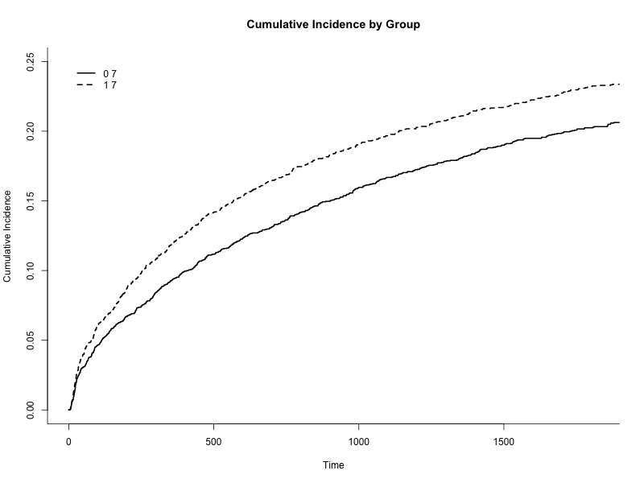

```r
knitr::include_graphics("SAVR_GI_cif.png")
```

```r
summary(fg_savr_otherbleed)
```

```
Competing Risks Regression

Call:
crr(ftime = matched_SAVR_data_otherbleed$ftime, fstatus = matched_SAVR_data_otherbleed$Event_name,
    cov1 = matched_SAVR_data_otherbleed$valve_type, failcode = 8,
    cencode = 0)

                                           coef exp(coef) se(coef)    z p-value
matched_SAVR_data_otherbleed$valve_type1 0.0996       1.1    0.043 2.32   0.021

                                         exp(coef) exp(-coef) 2.5% 97.5%
matched_SAVR_data_otherbleed$valve_type1       1.1      0.905 1.02   1.2

Num. cases = 7454
Pseudo Log-likelihood = -18756
Pseudo likelihood ratio test = 5.35  on 1 df,
```

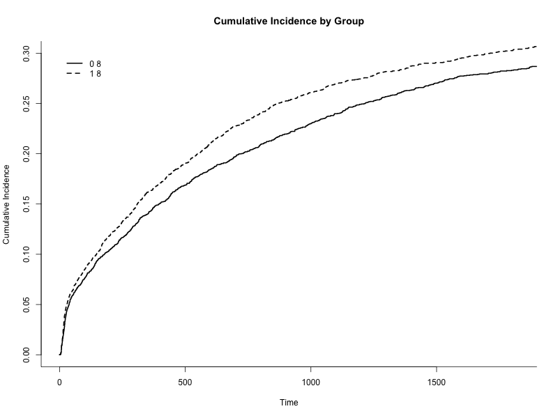

```r
knitr::include_graphics("SAVR_otherbleed_cif.png")
```

```r
summary(fg_savr_stroke)
```

```
Competing Risks Regression

Call:
crr(ftime = matched_SAVR_data_stroke$ftime, fstatus = matched_SAVR_data_stroke$Event_name,
    cov1 = matched_SAVR_data_stroke$valve_type, failcode = 9,
    cencode = 0)

                                        coef exp(coef) se(coef)      z p-value
matched_SAVR_data_stroke$valve_type1 -0.0288     0.972   0.0757 -0.381     0.7

                                     exp(coef) exp(-coef)  2.5% 97.5%
matched_SAVR_data_stroke$valve_type1     0.972       1.03 0.838  1.13

Num. cases = 5988
Pseudo Log-likelihood = -5923
Pseudo likelihood ratio test = 0.14  on 1 df,
```

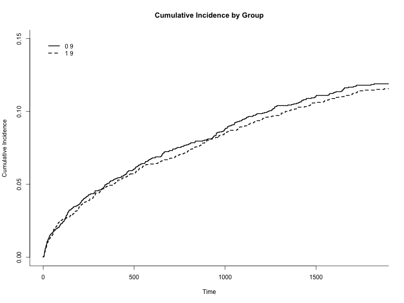

```r
knitr::include_graphics("SAVR_stroke_cif.png")
```

```r
summary(fg_tavr_reop)
```

```
Competing Risks Regression

Call:
crr(ftime = matched_TAVR_data_reop$ftime, fstatus = matched_TAVR_data_reop$Event_name,
    cov1 = matched_TAVR_data_reop$valve_type, failcode = 3, cencode = 0)

                                     coef exp(coef) se(coef)     z p-value
matched_TAVR_data_reop$valve_type1 0.0294      1.03    0.173 0.169    0.87

                                   exp(coef) exp(-coef)  2.5% 97.5%
matched_TAVR_data_reop$valve_type1      1.03      0.971 0.733  1.45

Num. cases = 6242
Pseudo Log-likelihood = -1120
Pseudo likelihood ratio test = 0.03  on 1 df,
```

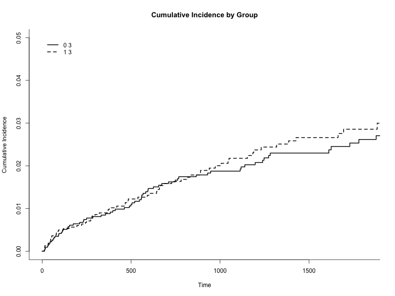

```r
knitr::include_graphics("TAVR_reop_cif.png")
```

```r
summary(fg_tavr_CHF)
```

```
Competing Risks Regression

Call:
crr(ftime = matched_TAVR_data_CHF$ftime, fstatus = matched_TAVR_data_CHF$Event_name,
    cov1 = matched_TAVR_data_CHF$valve_type, failcode = 4, cencode = 0)

                                   coef exp(coef) se(coef)     z p-value
matched_TAVR_data_CHF$valve_type1 -0.16     0.852   0.0907 -1.76   0.079

                                  exp(coef) exp(-coef)  2.5% 97.5%
matched_TAVR_data_CHF$valve_type1     0.852       1.17 0.714  1.02

Num. cases = 6599
Pseudo Log-likelihood = -4230
Pseudo likelihood ratio test = 3.09  on 1 df,
```

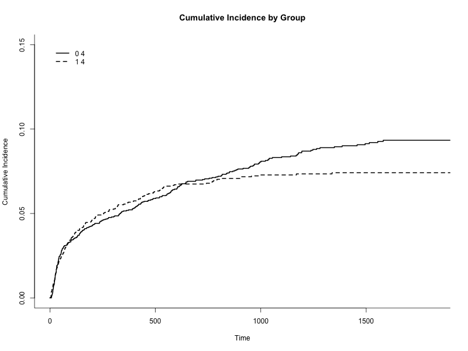

```r
knitr::include_graphics("TAVR_CHF_cif.png")
```

```r
summary(fg_tavr_endo)
```

```
Competing Risks Regression

Call:
crr(ftime = matched_TAVR_data_endo$ftime, fstatus = matched_TAVR_data_endo$Event_name,
    cov1 = matched_TAVR_data_endo$valve_type, failcode = 5, cencode = 0)

                                     coef exp(coef) se(coef)     z p-value
matched_TAVR_data_endo$valve_type1 -0.209     0.811    0.097 -2.15   0.031

                                   exp(coef) exp(-coef)  2.5% 97.5%
matched_TAVR_data_endo$valve_type1     0.811       1.23 0.671 0.981

Num. cases = 6543
Pseudo Log-likelihood = -3714
Pseudo likelihood ratio test = 4.67  on 1 df,
```

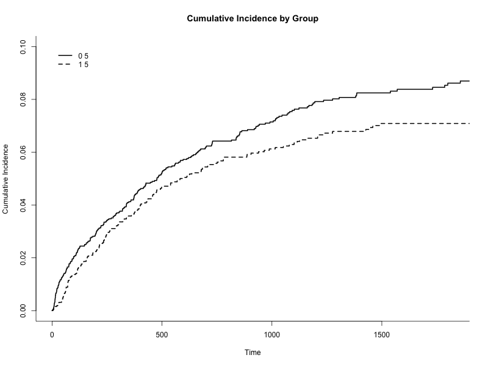

```r
knitr::include_graphics("TAVR_endo_cif.png")
```

```r
summary(fg_tavr_cerebral)
```

```
Competing Risks Regression

Call:
crr(ftime = matched_TAVR_data_cerebral$ftime, fstatus = matched_TAVR_data_cerebral$Event_name,
    cov1 = matched_TAVR_data_cerebral$valve_type, failcode = 6,
    cencode = 0)

                                         coef exp(coef) se(coef)      z p-value
matched_TAVR_data_cerebral$valve_type1 -0.159     0.853    0.162 -0.977    0.33

                                       exp(coef) exp(-coef)  2.5% 97.5%
matched_TAVR_data_cerebral$valve_type1     0.853       1.17 0.621  1.17

Num. cases = 6263
Pseudo Log-likelihood = -1303
Pseudo likelihood ratio test = 0.96  on 1 df,
```

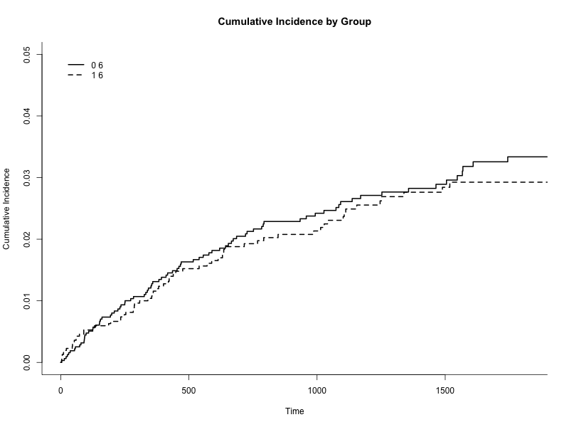

```r
knitr::include_graphics("TAVR_cerebral_cif.png")
```

```r
summary(fg_tavr_GI)
```

```
Competing Risks Regression

Call:
crr(ftime = matched_TAVR_data_GI$ftime, fstatus = matched_TAVR_data_GI$Event_name,
    cov1 = matched_TAVR_data_GI$valve_type, failcode = 7, cencode = 0)

                                   coef exp(coef) se(coef)     z p-value
matched_TAVR_data_GI$valve_type1 0.0177      1.02   0.0513 0.346    0.73

                                 exp(coef) exp(-coef)  2.5% 97.5%
matched_TAVR_data_GI$valve_type1      1.02      0.982 0.921  1.13

Num. cases = 7625
Pseudo Log-likelihood = -13134
Pseudo likelihood ratio test = 0.12  on 1 df,
```

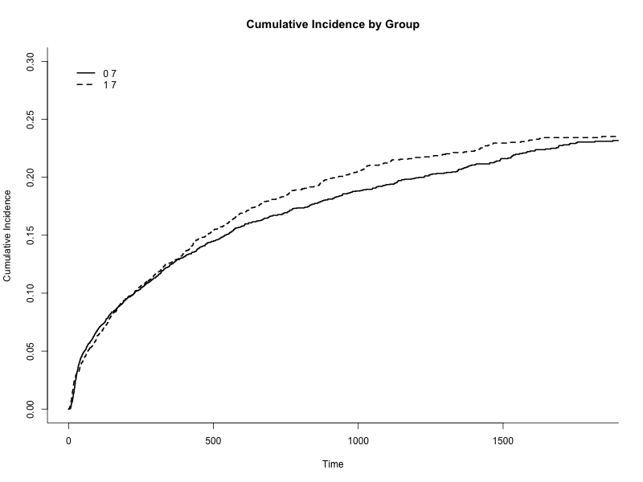

```r
knitr::include_graphics("TAVR_GI_cif.png")
```

```r
summary(fg_tavr_otherbleed)
```

```
Competing Risks Regression

Call:
crr(ftime = matched_TAVR_data_otherbleed$ftime, fstatus = matched_TAVR_data_otherbleed$Event_name,
    cov1 = matched_TAVR_data_otherbleed$valve_type, failcode = 8,
    cencode = 0)

                                           coef exp(coef) se(coef)     z
matched_TAVR_data_otherbleed$valve_type1 0.0352      1.04   0.0428 0.823
                                         p-value
matched_TAVR_data_otherbleed$valve_type1    0.41

                                         exp(coef) exp(-coef)  2.5% 97.5%
matched_TAVR_data_otherbleed$valve_type1      1.04      0.965 0.952  1.13

Num. cases = 8282
Pseudo Log-likelihood = -18974
Pseudo likelihood ratio test = 0.67  on 1 df,
```

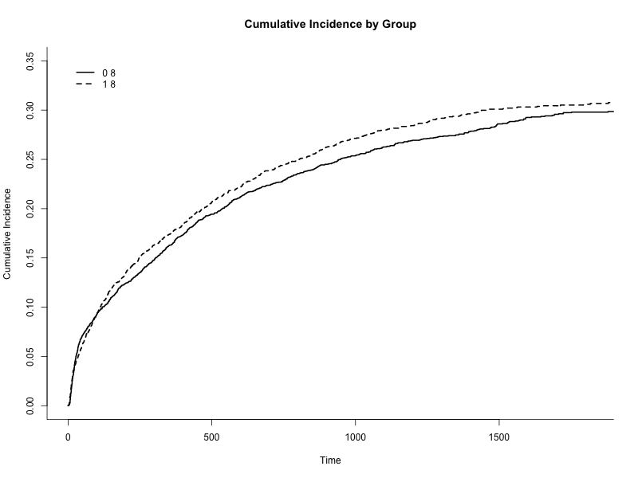

```r
knitr::include_graphics("TAVR_otherbleed_cif.png")
```

```r
summary(fg_tavr_stroke)
```

```
Competing Risks Regression

Call:
crr(ftime = matched_TAVR_data_stroke$ftime, fstatus = matched_TAVR_data_stroke$Event_name,
    cov1 = matched_TAVR_data_stroke$valve_type, failcode = 9,
    cencode = 0)

                                       coef exp(coef) se(coef)     z p-value
matched_TAVR_data_stroke$valve_type1 0.0645      1.07   0.0729 0.885    0.38

                                     exp(coef) exp(-coef)  2.5% 97.5%
matched_TAVR_data_stroke$valve_type1      1.07      0.938 0.925  1.23

Num. cases = 6859
Pseudo Log-likelihood = -6424
Pseudo likelihood ratio test = 0.78  on 1 df,
```

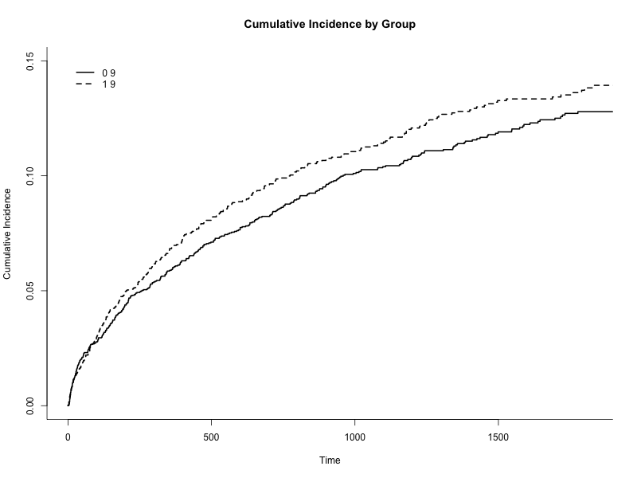

```r
knitr::include_graphics("TAVR_stroke_cif.png")
```

## 6 Reference

1. Austin PC, Fine JP. Practical recommendations for reporting fine-gray model analyses for competing risk data. Stat Med 2017;36(27):4391-4400.

2. Phan K, Zhao DF, Zhou JJ, Karagaratnam A, Phan S, Yan TD. Bioprosthetic versus mechanical prostheses for valve replacement in end-stage renal disease patients: Systematic review and meta-analysis. J Thorac Dis 2016;8(5):769-777.

3. Li GY, Chen YY, Chung FP, Chien KL, Hsu CP, Lin YJ. Long-term outcomes of bioprosthetic or mechanical valve replacement in end-stage renal disease: A nationwide population-based retrospective study. Front Cardiovasc Med 2021;8:745370.

4. Williams ML, Bavaria JE, Acker MA et al. Valve selection in end-stage renal disease: Should it always be biological? Ann Thorac Surg 2016;102(5):1531-1535.

5. Sharma T, Krishnan AM, Lahoud R, Polomsky M, Dauerman HL. National trends in tavr and savr for patients with severe isolated aortic stenosis. J Am Coll Cardiol 2022;80(21):2054-2056.

## 7 Supplemental Material

Codes for Data Cleaning

This set of codes cannot be executed locally on my personal computer. The dataset is only accessible through UPenn PMACS HSRDC - a virtual platform to ensure data security and maintain confidentiality.

```r
# Load data (replace this with your actual data loading code)
# ESRD_patients_medpar <- read.csv("path_to_your_data.csv")

# Define inclusion criteria: AVR
temp0521_1 <- ESRD_patients_medpar %>%
  mutate(
    DGNS_CD25 = DGNS_25_CD,
    Mechanical_AVR = 0,
    Bioprosthetic_AVR = 0,
    TAVR = 0,
    Procedure_date = NA
  ) %>%
  rowwise() %>%
  mutate(
    Mechanical_AVR = ifelse(any(c_across(starts_with("PRCDR_CD")) %in% c("3522", "02RF0JZ")), 1, 0),
    Bioprosthetic_AVR = ifelse(any(c_across(starts_with("PRCDR_CD")) %in% c("3521", "02RF07Z", "02RF08Z", "02RF0KZ")), 1, 0),
    TAVR = ifelse(
      any(substr(c_across(starts_with("PRCDR_CD")), 1, 5) %in% c("02RF3", "02RF4")) |
      any(substr(c_across(starts_with("PRCDR_CD")), 1, 4) %in% c("3505", "3506")),
      1,
      0
    ),
    Procedure_date = case_when(
      Mechanical_AVR == 1 ~ c_across(starts_with("PRCDR_DT"))[match("3522", c_across(starts_with("PRCDR_CD")))],
      Bioprosthetic_AVR == 1 ~ c_across(starts_with("PRCDR_DT"))[match("3521", c_across(starts_with("PRCDR_CD")))],
      TAVR == 1 ~ c_across(starts_with("PRCDR_DT"))[match(TRUE, substr(c_across(starts_with("PRCDR_CD")), 1, 5) %in% c("02RF3", "02RF4"))]
    )
  ) %>%
  ungroup()

# Filter rows where Mechanical_AVR, Bioprosthetic_AVR, and TAVR are all zero
temp0606 <- temp0521_1 %>%
  filter(!(Mechanical_AVR == 0 & Bioprosthetic_AVR == 0 & TAVR == 0))

# Process temp0606 to create temp0606_1
temp0606_1 <- temp0606 %>%
  mutate(
    multiple_valves = if_else(Mechanical_AVR + Bioprosthetic_AVR + TAVR > 1, 1, 0),
    exclu_comorbidity = 0
  ) %>%
  rowwise() %>%
  mutate(
    # Mark excluded comorbidities for PRCDR_CD variables
    exclu_comorbidity = if_else(
      any(c_across(starts_with("PRCDR_CD")) %in% c(
        "3523", "3524", "3510", "3511", "3513", "3514", "3527", "3528",
        "3507", "3508", "3525", "3526", "3804", "3814", "3834", "3844", "3845",
        "3864", "3971", "3973", "3978", "3509", "3520", "3596", "336", "3751",
        "3752", "375", "3753", "3754", "3755", "3760", "3762", "3763", "3765",
        "3766", "3768", "02RG0JZ", "02RG07Z", "02RG08Z", "02RG0KZ", "02QF",
        "02QH", "02WJ", "02RH", "02RJ", "02RX", "02RW", "02QX", "02QR", "02VX",
        "02VW", "02HX", "02HW", "04R0", "04Q0", "04V0", "04H0", "X2RF032",
        "02HA0QZ", "02HA0RJ", "02HA0RS", "02HA0RZ", "02HA3QZ", "02HA3RJ",
        "02HA3RS", "02HA3RZ", "02HA4QZ", "02HA4RJ", "02HA4RS", "02HA4RZ",
        "02RK07Z", "02RK08Z", "02RK0JZ", "02RK0KZ", "02RK47", "02RK47Z",
        "02RK48Z", "02RK4JZ", "02RK4KZ", "02RL07Z", "02RL08Z", "02RL0JZ",
        "02RL0KZ", "02RL47Z", "02RL48Z", "02RL4JZ", "02RL4KZ", "02UA0JZ",
        "02UA3JZ", "02UA4JZ", "02WA0JZ", "02WA0QZ", "02WA3QZ", "02YA0Z0",
        "02YA0Z1", "02YA0Z2", "5A02116", "5A0211D"
      ) |
      substr(c_across(starts_with("PRCDR_CD")), 1, 4) %in% c(
        "3523", "3524", "3510", "3511", "3513", "3514", "3527", "3528",
        "3507", "3508", "3525", "3526", "3804", "3814", "3834", "3844", "3845",
        "3864", "3971", "3973", "3978", "3509", "3520", "3596", "336", "3751",
        "3752", "375", "3753", "3754", "3755", "3760", "3762", "3763", "3765",
        "3766", "3768", "02QF", "02QH", "02WJ", "02RH", "02RJ", "02RX", "02RW",
        "02QX", "02QR", "02VX", "02VW", "02HX", "02HW", "04R0", "04Q0", "04V0",
        "04H0"
      ) |
      substr(c_across(starts_with("PRCDR_CD")), 1, 3) %in% c("336", "375")),
      1, exclu_comorbidity
    ),
    # Mark excluded comorbidities for DGNS_CD variables
    exclu_comorbidity = if_else(
      any(c_across(starts_with("DGNS_CD")) %in% c(
        "421", "4210", "4219", "4211", "4249", "42499", "42490", "42491",
        "11281", "03642", "09884", "11404", "11515", "11594", "I33", "I330",
        "I339", "I38", "I39", "A3951", "B376"
      ) |
      substr(c_across(starts_with("DGNS_CD")), 1, 4) %in% c(
        "4210", "4219", "4211", "4249", "I330", "I339", "B376"
      ) |
      substr(c_across(starts_with("DGNS_CD")), 1, 3) %in% c("421", "I33", "I38", "I39")),
      1, exclu_comorbidity
    )
  ) %>%
  ungroup() %>%
  select(-c(i)) # Drop intermediate variable `i`

# Create valve_AVR_0606
valve_AVR_0606 <- temp0606_1 %>%
  filter(multiple_valves == 0, exclu_comorbidity == 0)
```